# Logboek_NicoleB

## Logboek samenvatting

In dit logboek beschrijf ik mijn bijdrage aan het multi-omics project over thermogene lipolyse in bruine vetcellen. Ik heb me beziggehouden met de proteomicsdata, waarbij ik stap voor stap de preprocessing heb uitgevoerd van het verkennen van de ruwe data tot log2-transformatie, normalisatie en PCA. Daarnaast heb ik literatuur gelezen om mijn analyse te onderbouwen. Met limma heb ik DAP-lijsten opgesteld om significante eiwitverschillen tussen de tijdspunten 0h, 4h en 24h te laten zien. Ook om deze lijsten te gebruiken ook gemeenschappelijke pathways te vinden met transcriptomics, hiervoor werd metascape gebruikt. Metascape deel staat in Logboeken/Logboek_Gea.Rmd

## Projectstart

#### 20-04-2026

Als start heb ik met mijn groepje overlegd wat onze waarden zijn. Op basis daarvan heb ik deze samenwerkingsovereenkomst gemaakt:

- Elke les aanwezig tenzij anders overlegd.
- Afmelden bij ziekte en niet-tijdige aanwezigheid.
- Wekelijkse overleg wat er is gedaan en wat we gaan doen.
- Contact via Teams en WhatsApp.
- Deadlines worden vooraf afgesproken en nageleefd. Afspraak is afspraak.
- Taken worden eerlijk verdeeld en niet andermans taken doen zonder overleg.
- Als iemand deze overeenkomsten niet naleeft, behouden anderen het recht om naar de docent te stappen.

#### 21-04-2026

Dit is de link naar het wetenschappelijk artikel die wij gaan “nabootsen” https://www.sciencedirect.com/science/article/pii/S2589004225016438?via%3Dihub

Ze onderzoeken hoe bruine vetcellen reageren wanneer ze worden gestimuleerd om vet af te breken en warmte te produceren. Dit proces heet thermogene lipolyse en wordt in het experiment opgewekt door de cellen bloot te stellen aan norepinefrine. Tijdens dit experiment wordt op meerdere tijdstippen gemeten (0h, 4h, 24h).

Data staat nu op assemblix in het mapje Thema08

Github: https://github.com/Nikkieeex/Multi-omics_lypolysis_brown_adipocytes

#### 22-04-2026

Onze docent Tsjerk Wassenaar heeft vandaag uitleg gegeven over preproccesing. Ik heb daar wat notities over gemaakt en een stappenplan.

Stappen moeten chronologisch:

1. Artikel lezen (iedereen voorzich) Multi-omics analysis of thermogenic lipolysis in brown adipocytes
2. Vectorize data (Joris) Joris heeft alle data gedownload en we kijken naar welke bestanden nuttig zijn voor ons. Er zitten ook nog .raw data tussen en alle drie omics mogen nog gemapped worden tegen referentie genoom.

Wanneer deze eerste stap is afgerond gaat Joris een word document opstellen voor ons artikel. Tip van Tsjerk is kijk niet naar opmaakt en hou het simpel, vanwege het herformatteren van artikel later. Hoofdvraag artikel: focus op de methode in het artikel en niet hoofdvraag op biologie zetten

3. Ieder een omics (Gea, Janine, Nicole) Transcriptomics: Gea Metabolomics: Janine Proteomics: Nicole

Uiteindelijke resultaat is een numpy.array. Wanneer je klaar bent met jouw deel voordat andere dat zijn kun je het volgende doen. Kijk naar de hoofdvraag van het referentie artikel. Wat is er wel en niet onderzocht en hoe kunnen wij onze eigen draai geven.

Notes: Tsjerk heeft een library over regressie van tijd en het patroon in de data. Want we hebben verschillende tijdspunten (library heet chello). Dit kunnen we mogelijk later gebruiken na preprocessing stap.

Logboek inhoud: wat je doet. hoe (methode) en wat er uitkomt

## Literatuurstudie

#### 04-05-2026

Ik kwam op google scolar een mooi artikel tegen die mij een beter beeld gaf van protomics. https://www.mdpi.com/2073-4425/15/12/1551

Proteomics is namelijk een belangrijke aanvulling op transcriptomics, omdat eiwitexpressie niet altijd direct overeenkomt met genexpressie.

Ik heb ook een intressante tool gevonden genaamd MINIE. Het staat voor Multi-omic network inference from time-series data. Het is een machine learning tool die ik later wel zou willen uittesten. Ik heb hem gevonden in een artikel op pubmed https://pmc.ncbi.nlm.nih.gov/articles/PMC12521560/

#### 07-05-2026

Ik heb 2 wetenschappelijke artikelen gelezen die lijken op ons project en daar heb ik veel van opgestoken. https://pubmed.ncbi.nlm.nih.gov/41827860/ Een van deze was een review paper en heb ik veel opgestoken over bruine vetcellen. De belangrijkste conclusie uit deze studies is dat bruine vetcellen (BAT) veel complexer en belangrijker zijn dan vroeger gedacht. Ze zijn niet alleen “warmteproducerende vetcellen”, maar actieve metabole regelcentra. Er werden ook onderzoeken benoemd waar ze signaal eiwitten voor mogelijk endocriene verbanden en zelf darmmicrobiota verbanden zijn gevonden. We moeten wel voorzichtig conclusies trekken, omdat de meeste onderzoeken alleen nog op muizen zijn gedaan.

## Data verkenning

#### 08-05-2026

Ik heb een file aangemaakt genaamd Exploratory_Data_Analysis_proteomics.Rmd hier zet ik statestiek en visualisaties in om een beter begrip te krijgen van de data. Ik laad proteinGroups.txt in omdat hier samengevat in staat wat wij willen weten.( eiwitdata en LFQ-intensiteiten)

## Exploratory Data Analysis

Wat moet in mijn EDA: (voor mijzelf) Is mijn data bruikbaar? Zijn samples vergelijkbaar? Zijn er outliers/batch effects? Hoe zijn de intensiteiten verdeeld? Hoeveel missing values heb ik? Heb ik log-transformatie of extra normalisatie nodig?

Eerst data inladen die we willen beoordelen als het ware.

```r
library(tidyverse)
```

```r
library(pheatmap)
library(ggplot2)
# librarys alvast inladen voor later, doe ik graag in eerste code blok


file.exists("/students/2025-2026/Thema08/lipolyse/unpacked/proteomics//proteinGroups.txt") # Als er True staat bestaat het pad
data <- read.delim("/students/2025-2026/Thema08/lipolyse/unpacked/proteomics//proteinGroups.txt")
head(data)
```

Er komt bij mij True uit, dus we kunnen door! Ik ga nu kijken hoe de data in elkaar steekt.

```r
dim(data)
```

```
## [1] 4985  182
```

```r
colnames(data)
```

```
##   [1] "Protein.IDs"
##   [2] "Majority.protein.IDs"
##   [3] "Peptide.counts..all."
##   [4] "Peptide.counts..razor.unique."
##   [5] "Peptide.counts..unique."
##   [6] "Protein.names"
##   [7] "Gene.names"
##   [8] "Fasta.headers"
##   [9] "Number.of.proteins"
##  [10] "Peptides"
##  [11] "Razor...unique.peptides"
##  [12] "Unique.peptides"
##  [13] "Peptides.0h_01"
##  [14] "Peptides.0h_02"
##  [15] "Peptides.0h_03"
```

[output cut: 167 more lines]

Je ziet dat de data set 18 samples bevat van 6 replicaten op 0h, 6 replicaten op 4h en 6 replicaten op 24h

We gaan nu verder kijken naar LFQ.intensity. LFQ.intensity zijn de Label-Free Quantification waarden. Deze beschrijven de relatieve hoeveelheid van een eiwit in een sample.

Het bestand proteinGroups.txt is een samenvatting van de eiwitidentificaties uit MaxQuant (MaxQuant is a quantitative proteomics software package designed for analyzing large mass-spectrometric data sets). Elke rij stelt een eiwitgroep voor en de kolommen bevatten eigenschappen en metingen van deze eiwitgroep.

In Sequence.coverage staan de percentage van de aminozuursequentie dat gevonden is.

```r
lfq <- data[, grep("LFQ.intensity", colnames(data))]
head(lfq)
```

```
##   LFQ.intensity.0h_01 LFQ.intensity.0h_02 LFQ.intensity.0h_03
## 1            87921000            60332000            72508000
## 2                   0          5198300000                   0
## 3           213050000           141520000           245390000
## 4          4702600000          3715400000          4375400000
## 5            56831000            78211000            88756000
## 6                   0                   0                   0
##   LFQ.intensity.0h_04 LFQ.intensity.0h_05 LFQ.intensity.0h_06
## 1                   0            55431000            70794000
## 2          5980400000          6012800000                   0
## 3           187720000           179600000           214680000
## 4          4052300000          4561600000          3793900000
## 5                   0            61091000            72871000
## 6                   0                   0                   0
##   LFQ.intensity.24h_01 LFQ.intensity.24h_02 LFQ.intensity.24h_03
```

[output cut: 27 more lines]

Ik zie nullen dus we gaan dit even verder uitzoeken

```r
dim(lfq)
```

```
## [1] 4985   18
```

```r
summary(lfq)
```

```
##  LFQ.intensity.0h_01 LFQ.intensity.0h_02 LFQ.intensity.0h_03
##  Min.   :0.000e+00   Min.   :0.000e+00   Min.   :0.000e+00
##  1st Qu.:0.000e+00   1st Qu.:0.000e+00   1st Qu.:0.000e+00
##  Median :8.178e+07   Median :8.068e+07   Median :8.822e+07
##  Mean   :5.593e+08   Mean   :5.599e+08   Mean   :5.419e+08
##  3rd Qu.:2.738e+08   3rd Qu.:2.712e+08   3rd Qu.:2.883e+08
##  Max.   :1.025e+11   Max.   :1.009e+11   Max.   :7.096e+10
##  LFQ.intensity.0h_04 LFQ.intensity.0h_05 LFQ.intensity.0h_06
##  Min.   :0.000e+00   Min.   :0.000e+00   Min.   :0.000e+00
##  1st Qu.:0.000e+00   1st Qu.:0.000e+00   1st Qu.:0.000e+00
##  Median :7.463e+07   Median :7.399e+07   Median :8.958e+07
##  Mean   :5.780e+08   Mean   :5.828e+08   Mean   :5.568e+08
##  3rd Qu.:2.633e+08   3rd Qu.:2.649e+08   3rd Qu.:2.890e+08
##  Max.   :1.146e+11   Max.   :1.119e+11   Max.   :7.318e+10
##  LFQ.intensity.24h_01 LFQ.intensity.24h_02 LFQ.intensity.24h_03
##  Min.   :0.000e+00    Min.   :0.000e+00    Min.   :0.000e+00
##  1st Qu.:0.000e+00    1st Qu.:0.000e+00    1st Qu.:0.000e+00
##  Median :8.363e+07    Median :8.590e+07    Median :8.415e+07
##  Mean   :5.554e+08    Mean   :5.429e+08    Mean   :5.497e+08
##  3rd Qu.:2.725e+08    3rd Qu.:2.746e+08    3rd Qu.:2.766e+08
##  Max.   :7.911e+10    Max.   :7.431e+10    Max.   :7.616e+10
##  LFQ.intensity.24h_04 LFQ.intensity.24h_05 LFQ.intensity.24h_06
##  Min.   :0.000e+00    Min.   :0.000e+00    Min.   :0.000e+00
##  1st Qu.:0.000e+00    1st Qu.:0.000e+00    1st Qu.:0.000e+00
##  Median :7.928e+07    Median :8.680e+07    Median :8.113e+07
##  Mean   :5.535e+08    Mean   :5.381e+08    Mean   :5.439e+08
##  3rd Qu.:2.684e+08    3rd Qu.:2.751e+08    3rd Qu.:2.730e+08
##  Max.   :9.221e+10    Max.   :7.241e+10    Max.   :8.224e+10
##  LFQ.intensity.4h_01 LFQ.intensity.4h_02 LFQ.intensity.4h_03
##  Min.   :0.000e+00   Min.   :0.000e+00   Min.   :0.000e+00
##  1st Qu.:0.000e+00   1st Qu.:0.000e+00   1st Qu.:0.000e+00
##  Median :8.802e+07   Median :8.724e+07   Median :8.850e+07
##  Mean   :5.330e+08   Mean   :5.369e+08   Mean   :5.312e+08
##  3rd Qu.:2.885e+08   3rd Qu.:2.898e+08   3rd Qu.:2.862e+08
##  Max.   :7.429e+10   Max.   :7.256e+10   Max.   :7.916e+10
##  LFQ.intensity.4h_04 LFQ.intensity.4h_05 LFQ.intensity.4h_06
##  Min.   :0.000e+00   Min.   :0.000e+00   Min.   :0.000e+00
##  1st Qu.:0.000e+00   1st Qu.:0.000e+00   1st Qu.:0.000e+00
##  Median :9.094e+07   Median :8.437e+07   Median :9.121e+07
##  Mean   :5.197e+08   Mean   :5.539e+08   Mean   :5.288e+08
##  3rd Qu.:2.966e+08   3rd Qu.:2.764e+08   3rd Qu.:2.896e+08
##  Max.   :6.651e+10   Max.   :1.005e+11   Max.   :6.877e+10
```

[figure not shown]

```r
missing_per_protein <- rowSums(is.na(lfq))

hist(missing_per_protein, breaks = 18, main = "Missing Values Per Protein", xlab = "Aantal missende samples")
```

Er is een grote groep die nullen bevat. Veel eiwitten missen in meerdere samples doordat laag-abundante eiwitten niet altijd door de massaspectrometer worden gedetecteerd, waardoor eiwitten met extreem veel missende waarden later waarschijnlijk uit de analyse gefilterd zullen worden. Ik ga dit voor nu niet aanpassen. Dit is namelijk per tool die we later gaan gebruiken verschillend hoe ik dit moet aanpakken.

### Log

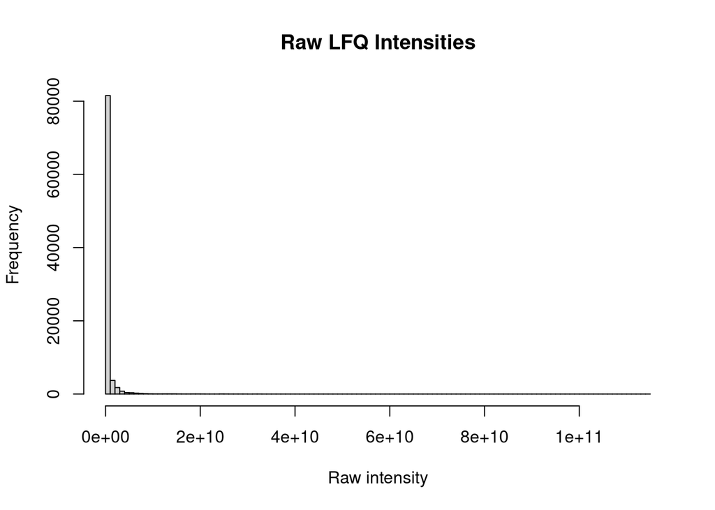

```r
hist(as.matrix(lfq), breaks = 100, main = "Raw LFQ Intensities", xlab = "Raw intensity")
```

De ruwe LFQ-intensiteiten zijn sterk rechts-scheef verdeeld, waarbij een klein aantal eiwitten extreem hoge abundanties heeft.

```r
lfq[lfq == 0] <- NA

lfq_log <- log2(lfq)
```

log2-transformatie toegepast om de verdeling compacter en beter vergelijkbaar te maken voor verdere statistische analyse.

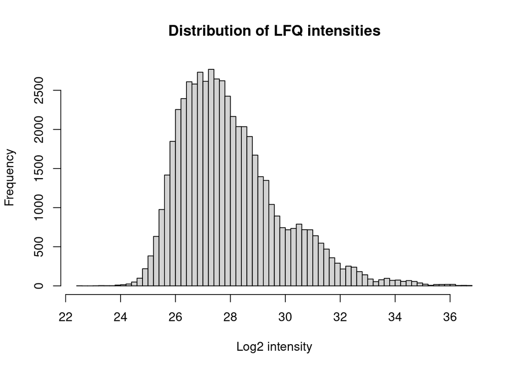

```r
hist(as.matrix(log2(lfq)), breaks = 100, main = "Distribution of LFQ intensities", xlab = "Log2 intensity")
```

Dit is een stuk beter

#### 09-05-2026

Op basis van ons gesprek met Marcel heb ik besloten om wat onderzoek te doen over de volgende stappen. Ik denk dat vooral dimensiereductie, DESeq2 en PLS goed passen bij ons onderzoek. Met dimensiereductie, zoals PCA, kunnen we eerst bekijken of de verschillende tijdspunten of condities van elkaar verschillen en of er outliers aanwezig zijn in de data. Dit geeft een eerste overzicht van de grootste patronen binnen de datasets.

Daarnaast lijkt DESeq2 mij geschikt voor de transcriptomicsdata, omdat deze methode speciaal ontwikkeld is voor RNA-seq countdata. Hiermee kunnen we onderzoeken welke genen significant verschillen tussen bijvoorbeeld 0, 4 en 24 uur.

Ook lijkt PLS of DIABLO erg nuttig voor ons onderzoek, omdat deze technieken meerdere omicslagen tegelijk kunnen integreren. Hierdoor kunnen verbanden tussen bijvoorbeeld transcriptomics, proteomics en metabolomics worden onderzocht. In het artikel wordt DIABLO (samen met MOFA) ook gebruikt voor de multi-omics analyse.

Wel denk ik dat we voorzichtig moeten zijn met heel complexe AI/ML methoden, omdat de datasets vaak relatief weinig samples bevatten. Hierdoor bestaat het risico op overfitting, wat ook in het artikel wordt benoemd. https://pubmed.ncbi.nlm.nih.gov/30657866/

#### 11-05-2016

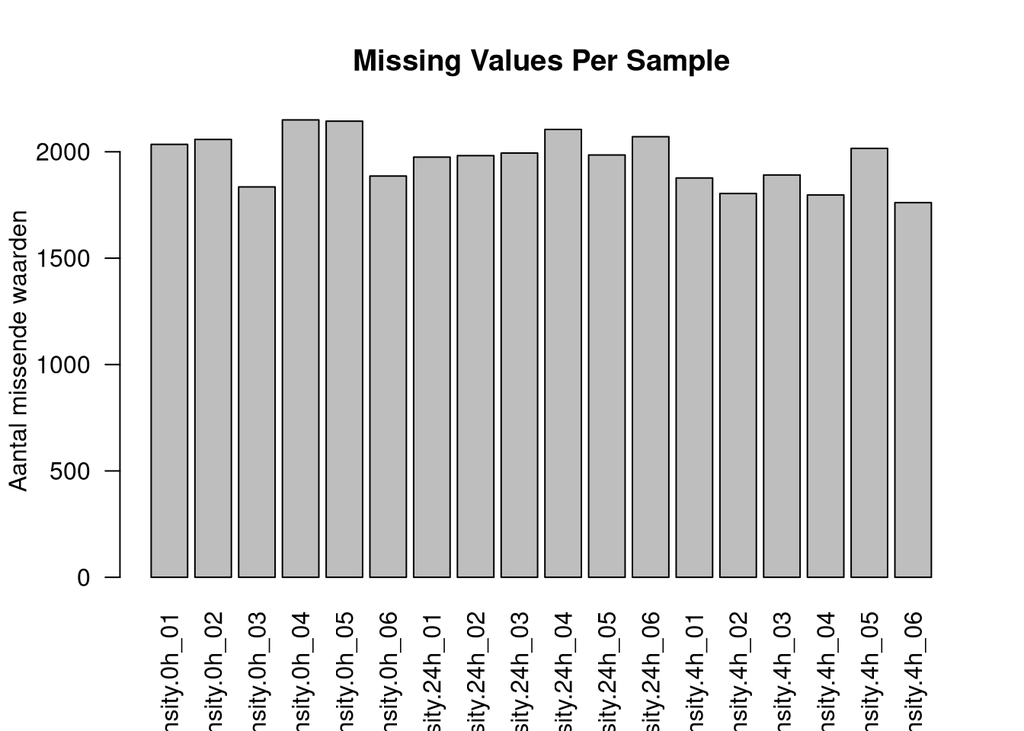

```r
missing_per_sample <- colSums(is.na(lfq))

barplot(missing_per_sample, las = 2, main = "Missing Values Per Sample", ylab = "Aantal missende waarden")
```

De missing values per sample is wel gelijk dus daar gaan we verder niet op in.

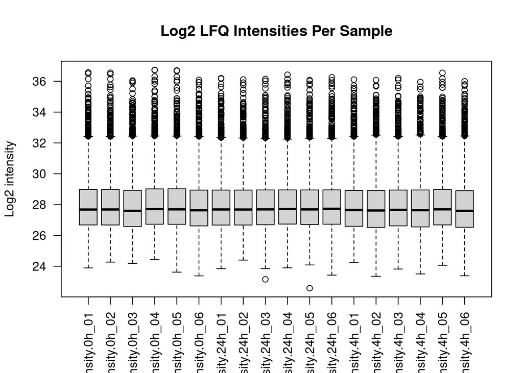

```r
boxplot(lfq_log, las = 2, main = "Log2 LFQ Intensities Per Sample", ylab = "Log2 intensity")
```

Er zijn hier ook geen samples die afwijken dus we gaan door

Deze grafiek doet het niet meer??? Ik kijk hier later naar

```r
data$mean_0h <- rowMeans(data[, grep("LFQ.intensity.0h", colnames(data))], na.rm = TRUE)

data$mean_24h <- rowMeans(data[, grep("LFQ.intensity.24h", colnames(data))], na.rm = TRUE)

data$log2_fc <- log2((data$mean_24h + 1) / (data$mean_0h + 1))

top_changed <- data %>%arrange(desc(abs(log2_fc)))

head(top_changed[, c("Gene.names", "log2_fc")], 20)
```

```
##            Gene.names   log2_fc
## 1                     -29.79423
## 2               Rpl39  28.36654
## 3                     -28.21415
## 4            Serpinc1  28.08149
## 5                Cd63 -27.68781
## 6              Ptprz1 -27.66983
## 7               Plin2  27.63887
## 8           Scd2;Scd3 -27.62001
## 9                Pdk4  27.31894
## 10              Rpl3l -27.11496
## 11                    -27.09020
## 12          Myl3;Myl1 -27.06865
## 13 Smap;1110004F10Rik  27.06375
## 14                Cfd  26.96732
## 15               Opa3 -26.96681
## 16             Cxcl12  26.94444
## 17             Pex11a -26.90916
## 18              Pex16 -26.85063
## 19                    -26.82857
## 20             Ndufa1  26.65711
```

#### 13-05-2026

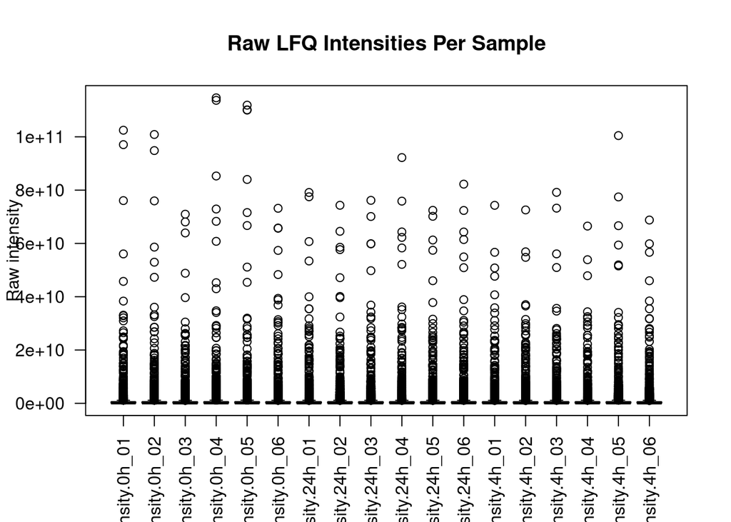

```r
boxplot(lfq, las = 2, main = "Raw LFQ Intensities Per Sample", ylab = "Raw intensity")
```

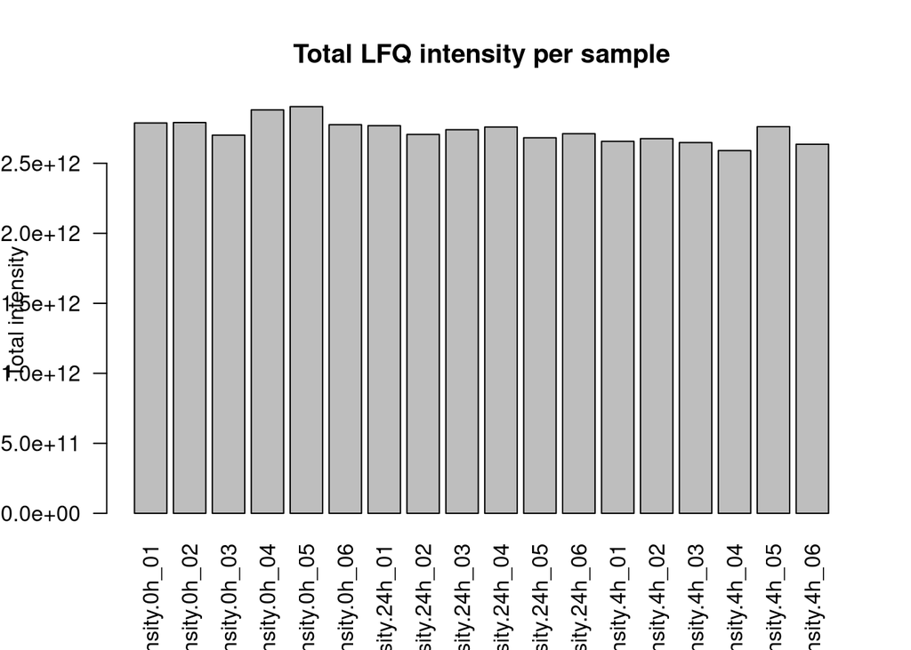

```r
sample_sums <- colSums(lfq, na.rm = TRUE)

barplot(sample_sums, las = 2, main = "Total LFQ intensity per sample", ylab = "Total intensity")
```

De ruwe LFQ-intensiteiten verschillen sterk in schaal en bevatten extreme waarden. Hierdoor zijn de distributies moeilijk onderling te vergelijken.

Ik ga eerst kijken naar al mogelijken patronen die te zien zijn in de data en dan kijken wat ik voor LFQ intensiteit kan betekenen als er geen patronen zijn.

## PCA & visualisaties

#### 14-05-2026

Ik ga kijken of ik in de data al patronen kan vinden met een heatmap

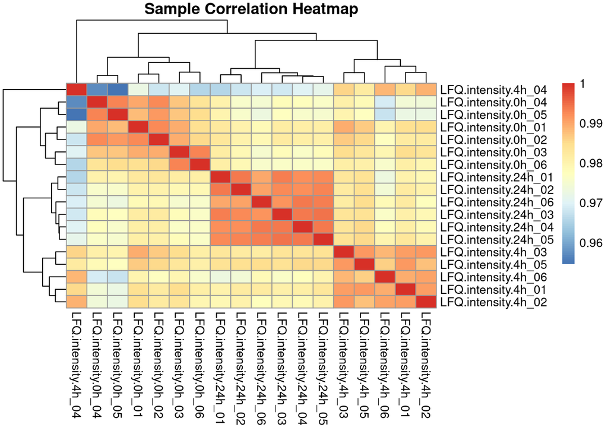

```r
cor_matrix <- cor(lfq_log, use = "pairwise.complete.obs")

pheatmap(cor_matrix, main = "Sample Correlation Heatmap")
```

De correlaties tussen samples zijn over het algemeen hoog (ongeveer 0.96–1.00). Daarnaast clusteren replicaten van dezelfde tijdspunten grotendeels samen. Er lijken geen extreme outliers of sterk afwijkende samples aanwezig te zijn. Dit suggereert dat de data technisch redelijk consistent is tussen samples.

In de volgende analyse gebruiken we een feature × feature correlatiematrix die Tsjerk ons aanraad. Hiermee onderzoeken we welke eiwitten gezamenlijk variëren tussen de verschillende tijdspunten.

##### PCA tsjerk methode

PCA (Principal Component Analysis) voeren we uit om grote en complexe datasets overzichtelijker te maken. We kijken namelijk naar veel voorkomende patronen https://en.wikipedia.org/wiki/Principal_component_analysis

```r
lfq_clean <- lfq
lfq_clean[lfq_clean == 0] <- NA

lfq_log_pca <- log2(lfq_clean)


lfq_log_pca <- lfq_log_pca[rowSums(is.na(lfq_log_pca)) == 0, ]
P <- t(as.matrix(lfq_log_pca))

P <- P[, apply(P, 2, sd) > 0]

vars <- apply(P, 2, var)
top_n <- min(500, ncol(P))

P <- P[, order(vars, decreasing = TRUE)[1:top_n]]

P <- scale(P)

svd_result <- svd(P)

loadings <- svd_result$v
scores <- P %*% loadings
vals <- svd_result$d^2
```

Met de eigenwaarden kan bekeken worden hoeveel variantie iedere principal component verklaart.

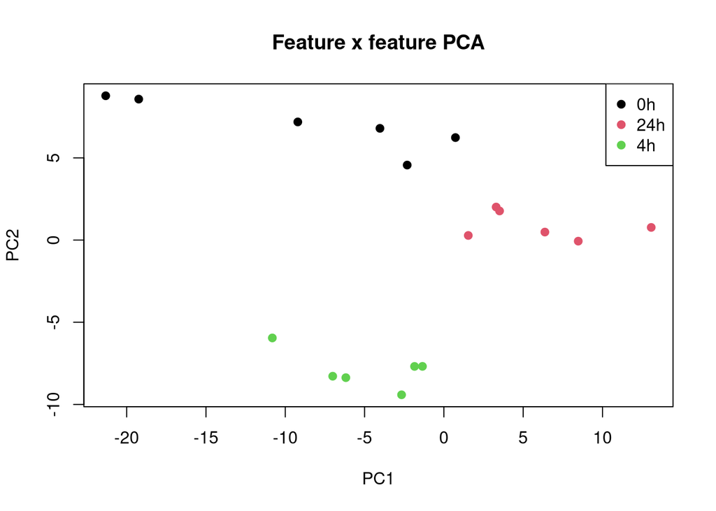

```r
groups <- c(rep("0h", 6), rep("4h", 6), rep("24h", 6))

plot(scores[,1],
     scores[,2],
     col = as.factor(groups),
     pch = 19,
     xlab = "PC1",
     ylab = "PC2",
     main = "Feature x feature PCA")

legend("topright", legend=levels(as.factor(groups)), col=1:3, pch=19)
```

Ik ben zeer tevreden met deze PCA1 vs PCA2!

De eerste principal components verklaren een groot deel van de variantie in de dataset. In de PCA-scoreplot is te zien dat de samples grotendeels clusteren per tijdspunt. Dit suggereert dat de eiwitprofielen veranderen tijdens thermogene lipolyse en dat de verschillende tijdspunten biologisch van elkaar verschillen.

Omdat de dataset veel meer features dan samples bevat, is voor de PCA eerst geselecteerd op de eiwitten met de hoogste variantie. Daarnaast is SVD gebruikt als numeriek stabielere methode voor dimensiereductie.

We maken nu een plot die laat zien hoeveel principal components relevant zijn om verder te analyseren.

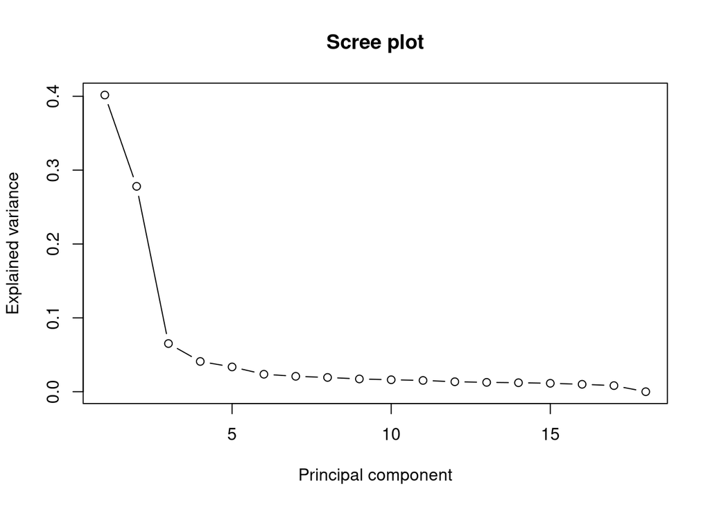

```r
plot(vals / sum(vals), type = "b", main = "Scree plot", xlab = "Principal component", ylab = "Explained variance")
```

De scree plot laat zien hoeveel variantie iedere principal component (PC) verklaart binnen de dataset. In deze analyse is duidelijk zichtbaar dat PC1 en PC2 het grootste deel van de variantie verklaren. PC1 verklaart ongeveer 40% van de variantie en PC2 iets minder dan 30%. Daarna daalt de hoeveelheid verklaarde variantie sterk.

Vanaf ongeveer PC3 wordt de lijn veel vlakker.

Op basis van deze scree plot kan geconcludeerd worden dat de dataset grotendeels wordt verklaard door een klein aantal principal components. Daarom zijn vooral PC1 en PC2 relevant voor verdere visualisatie en interpretatie van de proteomics- of transcriptomicsdata. Dit ondersteunt het gebruik van PCA om biologische verschillen tussen de samples inzichtelijk te maken.

#### 16-05-2026

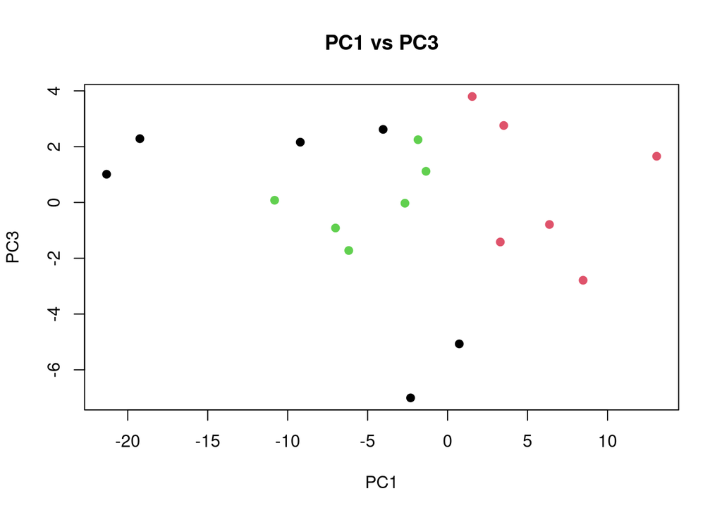

```r
plot(scores[,1], scores[,3], col=as.factor(groups), pch=19, xlab="PC1", ylab="PC3", main="PC1 vs PC3")
```

Ik weet niet zo goed hoe ik dit moet interpreteren.

Voor meer overzicht PCA loop!

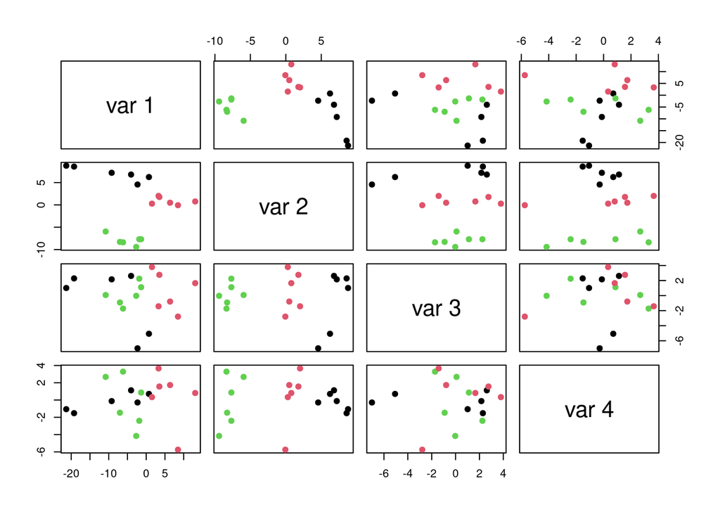

```r
pairs(scores[,1:4], col=as.factor(groups),pch=19)
```

Ik ben trouwens de legenda vergeten maar heeft zelfde betekenis als PCA1 VS PCA2

Je ziet hier dat er wel clusters ontstaan tussen PCA2 en andere PCA. Dit is wel intressant

#### 17-05-2026

Nog even wat plots maken die PCA ondersteunen

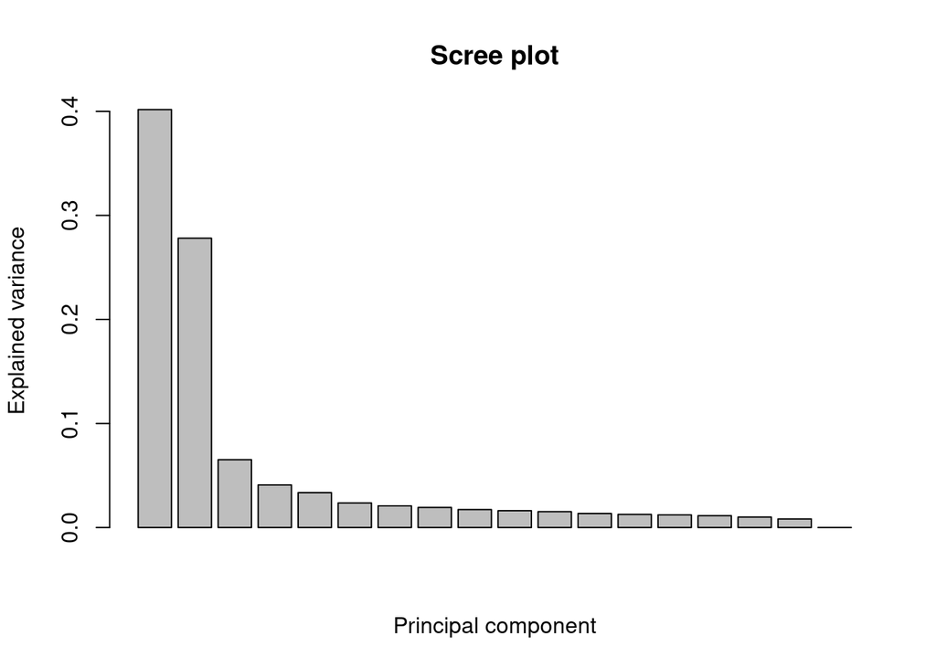

```r
explained <- vals / sum(vals)
barplot(explained, xlab="Principal component", ylab="Explained variance", main="Scree plot")
```

Zelfde als eerste scree plot maar dan histrogram. Ik twijfel nog welke duidelijker is voor midterm presentatie

#### 19-05-2026

Nog even opschrijven wat ik had gevonden later tabladen staan nog open

## ML voorbereiding

#### 22-05-2026

Ik heb na de midterm reviw presentatie naar wat opties gekeken waar ons project naartoe kan gaan en ik kwam bij MOFA+

https://pmc.ncbi.nlm.nih.gov/articles/PMC7212577/

#### 24-05-2026

Vandaag heb ik gewerkt aan het geschikt maken van de proteomicsdataset voor integratie met MOFA+. In de literatuur wordt benadrukt dat een belangrijke beperking van MOFA+ is dat het model zorgvuldige preprocessing vereist. Dit komt doordat MOFA+ probeert onderliggende biologische signalen te extraheren uit complexe datasets, terwijl ruwe omics-data vaak verstoord wordt door technische en statistische factoren. Voorbeelden van zulke verstoringen zijn:

technische ruis batch effects verschillende distributies tussen datasets extreme waarden missing values

Omdat MOFA+ gevoelig kan zijn voor deze factoren, is het belangrijk om kritisch te evalueren welke preprocessing-stappen noodzakelijk zijn voor mijn dataset.

Een van de eerste keuzes die gemaakt moest worden, is hoe om te gaan met missing values. In proteomicsdata komen missende waarden vaak voor door detectielimieten van de massaspectrometer, en in veel gevallen moeten deze gefilterd of geïmputeerd worden. Mijn eerste aanname was daarom dat filtering van eiwitten met veel missende waarden noodzakelijk zou zijn voordat de data gebruikt kan worden in MOFA+. Om dit te controleren heb ik het aantal missende waarden per eiwit berekend:

```r
table(rowSums(is.na(lfq_log)))
```

```
##
##    0    1    2    3    4    5    6    7    8    9   10   11   12   13   14   15
## 2273  176  114   84   70   64   66   65   60   55   58   66   66   87  106  137
##   16   18
##  184 1254
```

#### 25-05-2026

Ik ga nu kijken naar de scaling

In de literatuur wordt vaak aangeraden om data te schalen, omdat verschillen in schaal tussen features het model kunnen beïnvloeden. Toch is het belangrijk vind ik om eerst te evalueren of deze stap in mijn specifieke dataset daadwerkelijk nodig is.

Om dit te onderzoeken heb ik de data vóór en na scaling met elkaar vergeleken. De scaling is uitgevoerd met z-score normalisatie per eiwit:

```r
lfq_scaled <- t(scale(t(lfq_log)))
```

Nu kijken met boxplot of er ook echt verschillen zijn

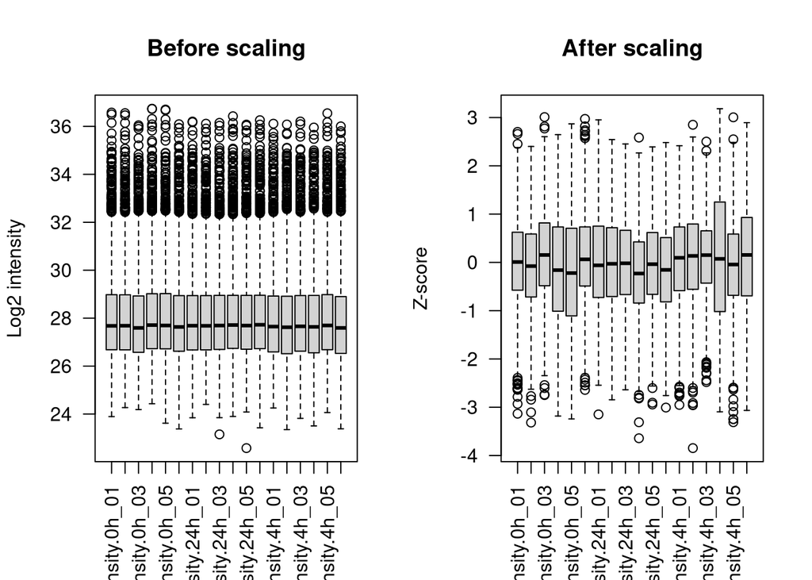

```r
par(mfrow = c(1, 2))
# VOOR scaling
boxplot(lfq_log, las = 2, main = "Before scaling", ylab = "Log2 intensity")
# NA scaling
boxplot(lfq_scaled, las = 2, main = "After scaling", ylab = "Z-score")
```

```r
par(mfrow = c(1,1))
```

Daarnaast is duidelijk dat de schaal volledig is veranderd van absolute intensiteiten (log2) naar relatieve waarden (z-scores).

## Feature selectie

Na het schalen van de data heb ik de volgende stap uitgevoerd: het selecteren van de meest informatieve eiwitten voor gebruik in MOFA+. Omdat de dataset veel meer eiwitten dan samples bevat, is het belangrijk om ruis te verminderen en de analyse te focussen op de belangrijkste variatie.

```r
vars <- apply(lfq_scaled, 1, var)

summary(vars)
```

```
##    Min. 1st Qu.  Median    Mean 3rd Qu.    Max.    NA's
##       1       1       1       1       1       1    2712
```

Omdat de data vooraf is geschaald met z-score normalisatie, is de variantie per eiwit gelijk gemaakt. Hierdoor is variantie geen geschikte maat meer om informatieve eiwitten te selecteren. In plaats daarvan is gebruik gemaakt van de PCA-analyse, die laat zien dat de dataset al duidelijke biologische structuur bevat en geen verdere filtering vereist.

#### 26-05-2026

Na het uitvoeren van log-transformatie, controle op missing values en scaling, heb ik een uiteindelijke data matrix af

```r
dim(lfq_scaled)
```

```
## [1] 4985   18
```

Matrix een naampje geven. Makkelijker terug te vinden op deze manier.

```r
proteomics_matrix <- lfq_scaled
```

Ik ga nu noteren wat ik heb gedaan in onze paper. Hier kun je nog even kijken hoe matrix eruit ziet.

```r
head(proteomics_matrix)
```

```
##      LFQ.intensity.0h_01 LFQ.intensity.0h_02 LFQ.intensity.0h_03
## [1,]           1.7886165        -0.552556834           0.5903408
## [2,]                  NA         0.710864516                  NA
## [3,]           0.6199276        -1.131194748           1.2248665
## [4,]           1.8278750        -0.139108704           1.2258522
## [5,]          -1.5860424        -0.007625048           0.6175602
## [6,]                  NA                  NA                  NA
##      LFQ.intensity.0h_04 LFQ.intensity.0h_05 LFQ.intensity.0h_06
## [1,]                  NA          -1.0792837          0.44161368
## [2,]          1.48879900           1.5187888                  NA
## [3,]          0.07811222          -0.1111719          0.65255270
## [4,]          0.58546530           1.5737506          0.03542836
## [5,]                  NA          -1.2287546         -0.35718675
## [6,]                  NA                  NA                  NA
##      LFQ.intensity.24h_01 LFQ.intensity.24h_02 LFQ.intensity.24h_03
```

[output cut: 27 more lines]

#### 28-05-2026

matrix rows aanpassen zodat ze matchen met transcriptomics matrix. Dit is nu ons prioriteit zodat we nog iets van een vergelijking kunnnen toepassen voor de deadline.

```r
file.exists("/students/2025-2026/Thema08/lipolyse/unpacked/proteomics//proteinGroups.txt") # Als er True staat bestaat het pad
```

```
## [1] TRUE
```

```r
data <- read.delim("/students/2025-2026/Thema08/lipolyse/unpacked/proteomics//proteinGroups.txt")

colnames(data)
```

```
##   [1] "Protein.IDs"
##   [2] "Majority.protein.IDs"
##   [3] "Peptide.counts..all."
##   [4] "Peptide.counts..razor.unique."
##   [5] "Peptide.counts..unique."
##   [6] "Protein.names"
##   [7] "Gene.names"
##   [8] "Fasta.headers"
##   [9] "Number.of.proteins"
##  [10] "Peptides"
##  [11] "Razor...unique.peptides"
##  [12] "Unique.peptides"
##  [13] "Peptides.0h_01"
##  [14] "Peptides.0h_02"
##  [15] "Peptides.0h_03"
```

[output cut: 167 more lines]

```r
head(data$Gene.names)
```

```
## [1] "Mtnd4;ND4;mt-Nd4;Nd4"        "Atp8;mt-Atp8;ATP8;Mtatp8"
## [3] "Mtnd5;ND5;mt-Nd5;Nd5;mt-Nd6" "COX2;mt-Co2;COXII;Mtco2"
## [5] "Pten"                        "mt-Nd2;ND2;Mtnd2"
```

Voor duidelijkheid ik heb vanaf begin LFQ files gebruikt waar geen IDs in stonden.

Let op Joris als je ML gebruikt zorg dat 0 waardes okay zijn want 30% is 0 anders vervangen door kleine waardes. Ik doe het hier even voor je maar ik weet niet of dit goed genoeg is. Let hier even extra op.

```r
proteomics_matrix_imp <- proteomics_matrix
proteomics_matrix_imp[proteomics_matrix_imp == 0] <- NA

# vervang NA met kleine waarde
min_val <- min(proteomics_matrix_imp, na.rm = TRUE)

proteomics_matrix_imp[is.na(proteomics_matrix_imp)] <- min_val * 0.5
head(proteomics_matrix_imp, 50)
```

```
##       LFQ.intensity.0h_01 LFQ.intensity.0h_02 LFQ.intensity.0h_03
##  [1,]          1.78861651        -0.552556834         0.590340795
##  [2,]         -1.92284286         0.710864516        -1.922842855
##  [3,]          0.61992759        -1.131194748         1.224866505
##  [4,]          1.82787498        -0.139108704         1.225852201
##  [5,]         -1.58604242        -0.007625048         0.617560217
##  [6,]         -1.92284286        -1.922842855        -1.922842855
##  [7,]         -1.92284286        -1.922842855        -1.922842855
##  [8,]         -1.92284286        -1.922842855        -1.922842855
##  [9,]          0.18478639         0.948130952        -0.389887547
## [10,]         -0.55254069        -1.922842855        -0.312342129
## [11,]          1.03681560         1.192379852         0.009514035
## [12,]         -1.92284286        -1.922842855        -1.922842855
## [13,]         -1.92284286        -1.922842855        -1.922842855
## [14,]         -0.82500937        -0.076945241         0.563155035
```

[output cut: 291 more lines]

Lage getallen inplaats van nullen. Veel modellen kunnen er op deze manier beter mee werken.

## DAP-lijsten met Limma

#### 29-05-2026

Ik heb weer een PVA gemaakt over de laatste stappen van ons project. Deze is te vinden in onze Microsoft Teams kanaal. Dit is wat ik ga doen aankomende dagen:

- Maak DAP-lijsten (differentially abundant proteins) voor de 3 vergelijkingen (0h vs 4h, ect.).
- Exporteer de lijsten met: gen ID / gene symbol + log2FC + p-value + padj.
- Maak een overlap-lijst met de DEG-lijsten van Joris (welke genen komen in beide voor).

#### 31-05-2026

We hebben besloten om metascape te gebruiken om de proteomics en transcriptomics te vergelijken. We doen eerst even een check voordat we DAP lijsten maken.

We gaan Limma gebruiken. Limma spoort statistisch significante verschillen op in genexpressie tussen verschillende biologische groepen. Bij ons dus de tijdsgroepen.Vandaar de keuze om limma te gebruiken, ook vanwege populairiteit. Joris (groepsgenootje) gebruikt ook limma.

Door het Empirical Bayes-algoritme deelt Limma variantie-informatie over alle eiwitten heen. Dit voorkomt fouten (valse positieven) wanneer je slechts 3 of 4 herhalingen (replicates) per groep hebt

```r
library(limma)
library(tidyverse)

dim(proteomics_matrix)
```

```
## [1] 4985   18
```

```r
head(rownames(proteomics_matrix))
```

```r
prot_clean <- proteomics_matrix_imp
prot_clean[prot_clean == 0] <- NA
prot_log <- log2(as.matrix(prot_clean))
min_log_val <- min(prot_log, na.rm = TRUE)
prot_log[is.na(prot_log)] <- min_log_val - 1

cat("Waardenbereik prot_log:", range(prot_log, na.rm = TRUE))
```

```
## Waardenbereik prot_log: -14.48092 1.670342
```

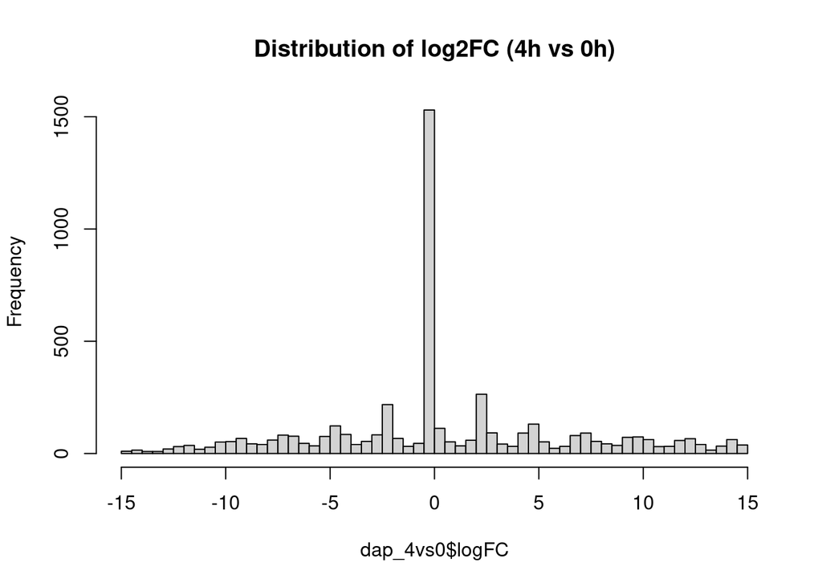

```r
group <- factor(c(rep("h0",6), rep("h24",6), rep("h4",6)), levels = c("h0", "h4", "h24")) # kolommen stonden eerst in de war hehehe dit was de nodige fix
design <- model.matrix(~0 + group)
colnames(design) <- levels(group)

contr.matrix <- makeContrasts(h4_vs_h0  = h4  - h0, h24_vs_h0 = h24 - h0, h24_vs_h4 = h24 - h4, levels =design)

fit  <- lmFit(prot_log, design)
fit2 <- contrasts.fit(fit, contr.matrix)
fit2 <- eBayes(fit2, trend = TRUE)


dap_4vs0 <- topTable(fit2, coef = "h4_vs_h0", number = Inf, adjust.method = "BH")
hist(dap_4vs0$logFC, breaks = 100, main = "Distribution of log2FC (4h vs 0h)")
```

```r
cat("Value range:", range(prot_log, na.rm = TRUE), "\n")
```

```
## Value range: -14.48092 1.670342
```

```r
cat("Expected: roughly 10 to 40 for LFQ log2 intensities\n")
```

```
## Expected: roughly 10 to 40 for LFQ log2 intensities
```

```r
cat("Dimensions:", dim(prot_log), "\n")
```

```
## Dimensions: 4985 18
```

```r
dap_4vs0  <- topTable(fit2, coef = "h4_vs_h0",  number = Inf, adjust.method = "BH")
dap_24vs0 <- topTable(fit2, coef = "h24_vs_h0", number = Inf, adjust.method = "BH")
dap_24vs4 <- topTable(fit2, coef = "h24_vs_h4", number = Inf, adjust.method = "BH")

dap_4vs0$ensembl_gene_id  <- rownames(dap_4vs0)
dap_24vs0$ensembl_gene_id <- rownames(dap_24vs0)
dap_24vs4$ensembl_gene_id <- rownames(dap_24vs4)
dap_4vs0  <- dap_4vs0[,  c("ensembl_gene_id", "logFC", "P.Value", "adj.P.Val")]
dap_24vs0 <- dap_24vs0[, c("ensembl_gene_id", "logFC", "P.Value", "adj.P.Val")]
dap_24vs4 <- dap_24vs4[, c("ensembl_gene_id", "logFC", "P.Value", "adj.P.Val")]
all_daps <- rbind(
  cbind(dap_4vs0,  comparison = "4h_vs_0h"),
  cbind(dap_24vs0, comparison = "24h_vs_0h"),
  cbind(dap_24vs4, comparison = "24h_vs_4h")
)
sig_daps <- all_daps[all_daps$adj.P.Val < 0.05 & abs(all_daps$logFC) > 1, ] #drempel waarden waar ik het over heb onder code block
print(paste("Significante DAPs:", nrow(sig_daps)))
```

```
## [1] "Significante DAPs: 2759"
```

```r
write.csv(dap_4vs0,  "DAP_4h_vs_0h.csv",  row.names = FALSE)
write.csv(dap_24vs0, "DAP_24h_vs_0h.csv", row.names = FALSE)
write.csv(dap_24vs4, "DAP_24h_vs_4h.csv", row.names = FALSE)
write.csv(all_daps,  "All_DAPs_combined.csv", row.names = FALSE)
```

De lijsten staan nu in in Multi-omics_lypolysis_brown_adipocytes_lists